# 2021 Q

Jake Cavaiani

12/9/2021

### 2021

Vault, French, and Moose only have data from 6/29 on due to data not being uploaded to the drive before the computer had water damage and lost the data….reminder to ALWAYS BACK UP DATA. We can try and run a model to apply data from Poker to extrapolate missing water level points at other sites.

2021 data comes from DoD Project-> 2021 AK sensors -> Discharge->PT->‘site’

2021 data was taken using a Wading rod and salt slug dilution and an ADCP at Stuart and Moose one time during the season.

NEON air pressure data

# Moose

### Raw Moose PT1

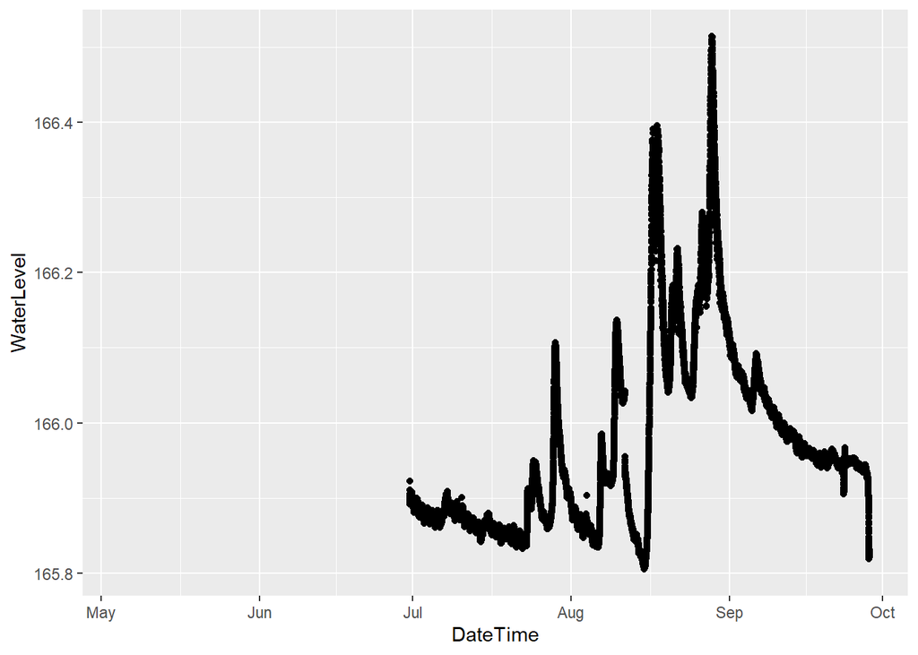

Need to clean out of water points at the end of the dataframe…let the cleaning commence!

### Moose PT1 2.0

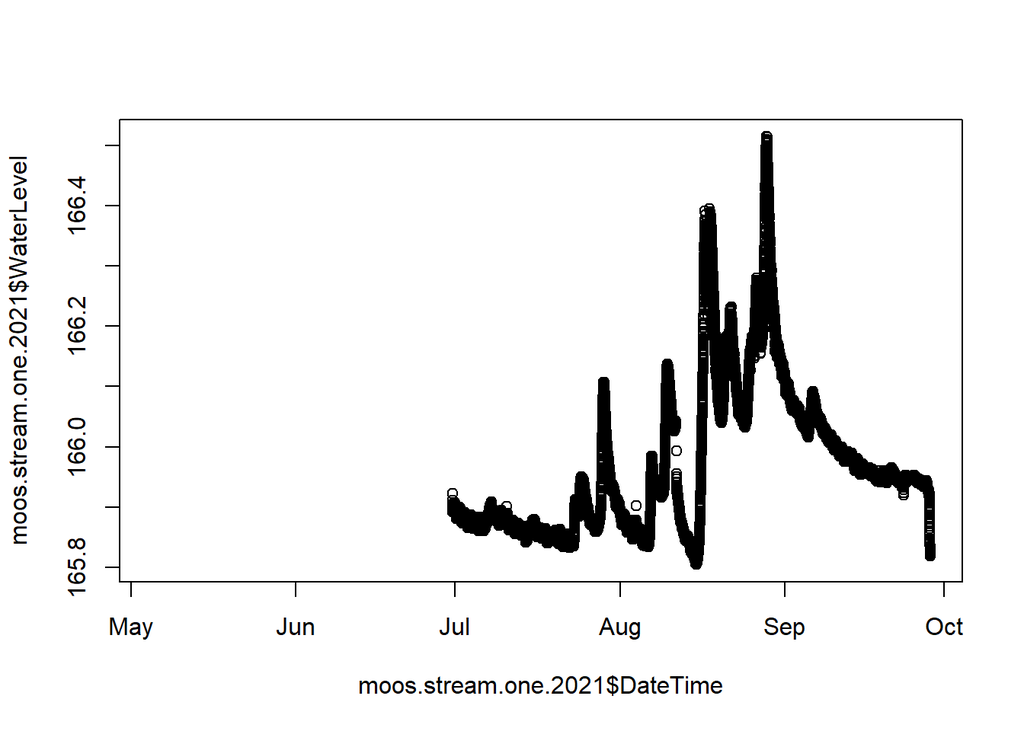

### Raw Moose PT2

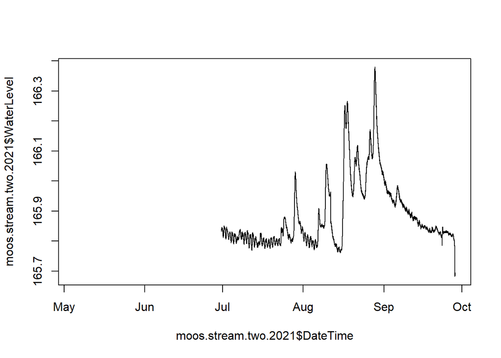

Need to remove out of water points associated with decommission…let the cleaning commence!

### Moose PT2 2.0

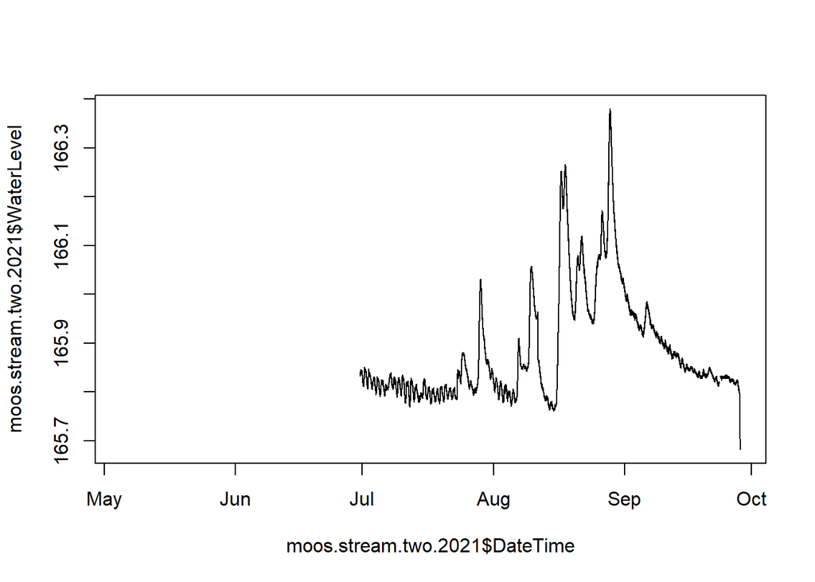

## Export PT data to csv in DoD_Discharge->PT_data->2021

## Raw rating curve for MOOS PT1

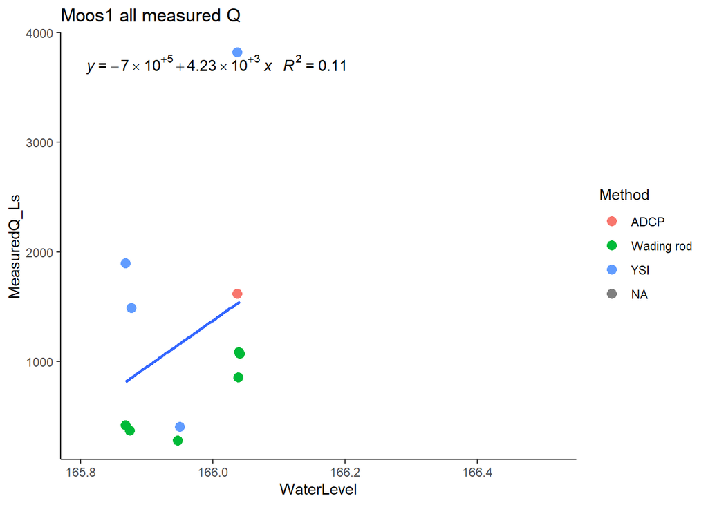

High YSI pints will have to be removed

### MOOS PT1 2.0

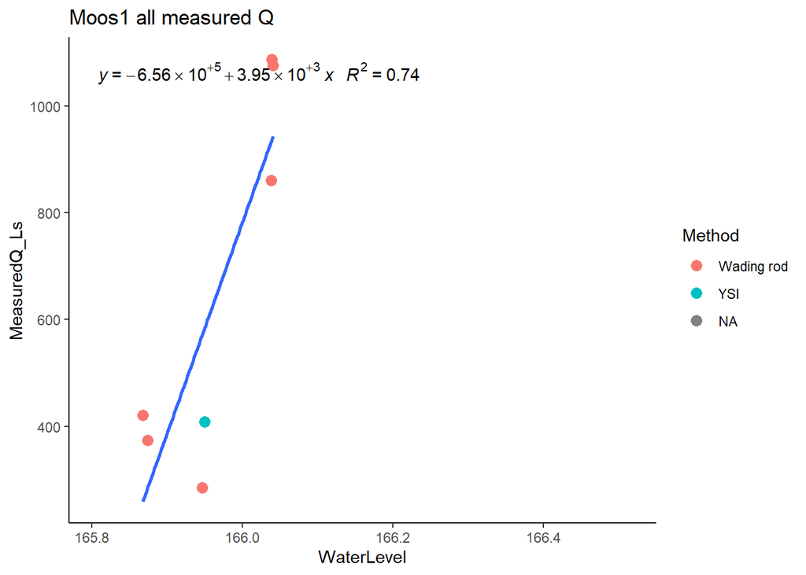

1. removed YSI points above 1000 Ls

## Raw rating curve for MOOS PT2

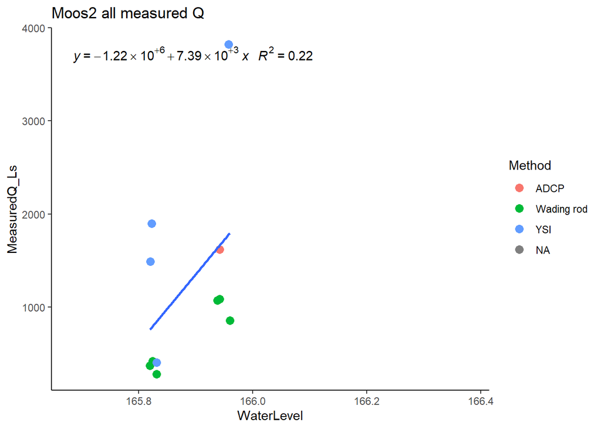

Need to remove YSI’s

### MOOS PT2

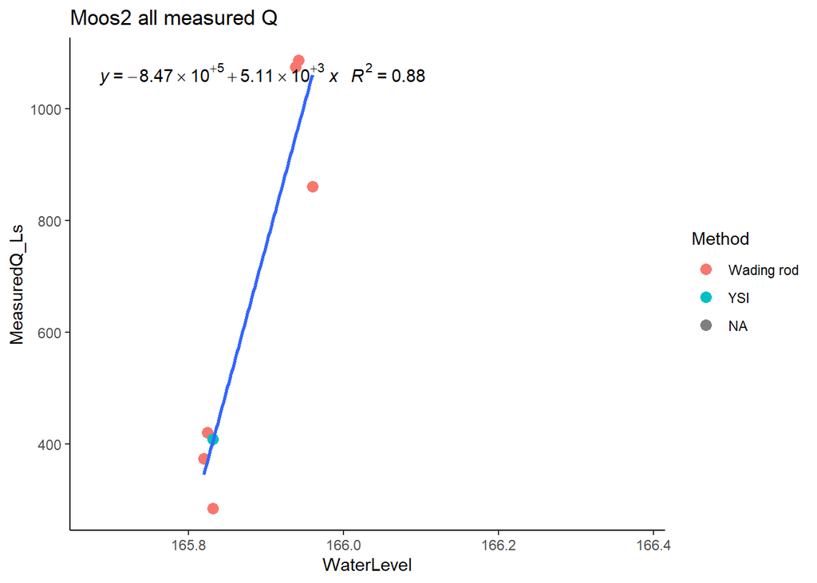

1. removed YSI points above 1200 Ls

### Predicted Q MOOS PT1

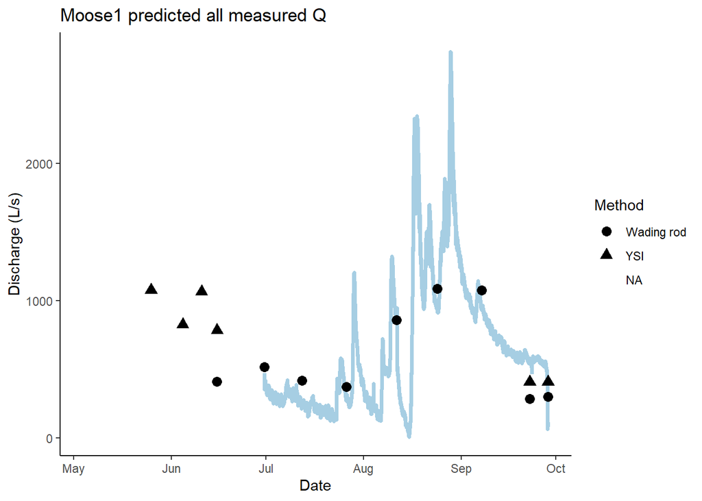

Not too shabby

### Predicted Q MOOS PT2

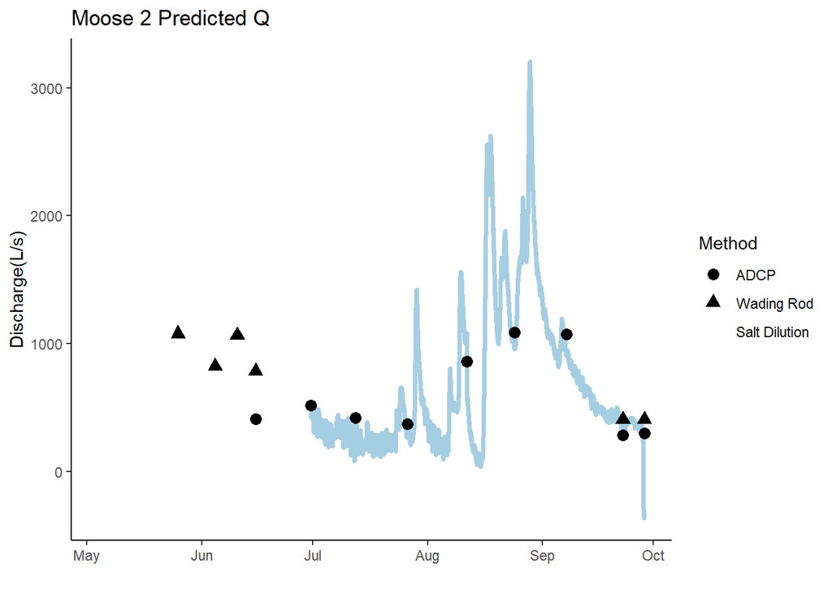

Not too shabby

### Average predicted Q MOOS

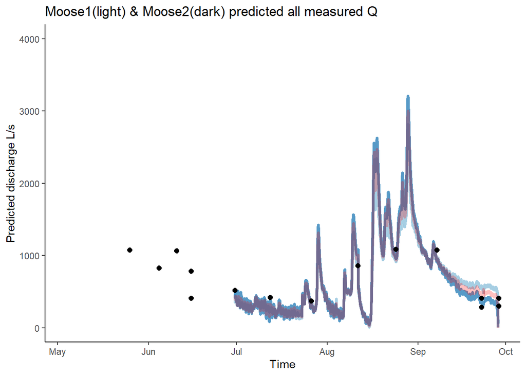

Looks good and red should be exported as a csv

## Export PT data to csv in DoD_Discharge->Predicted_discharge->2021

# French

### Raw French PT1

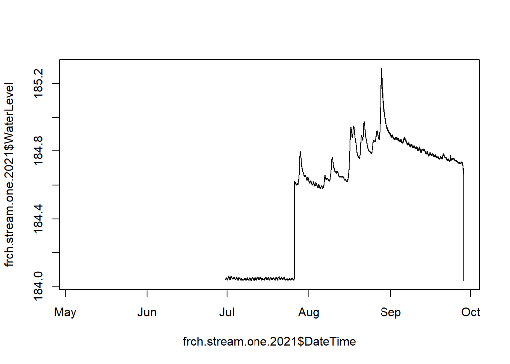

It appears that I need to shift the July data up to what it looks like to the end of July and take the out of water points associated with decommission out of data frame

### French PT1 2.0

```
## [1] 0.568
```

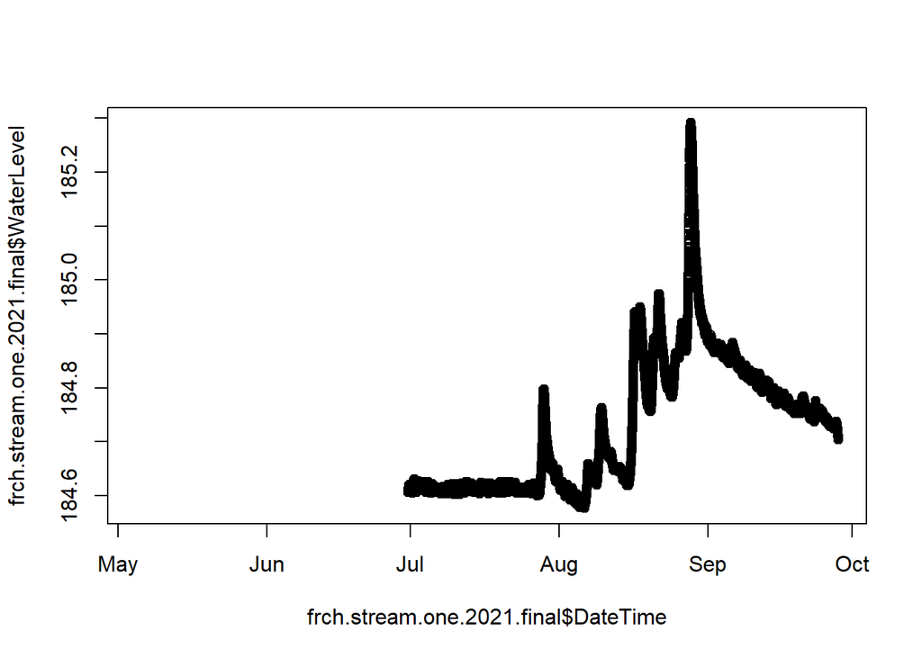

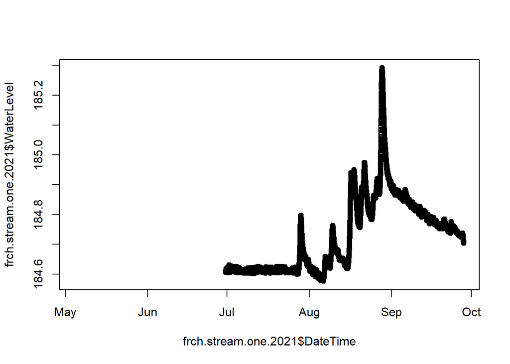

1) removed out of water points associated with decommission 2) shifted July data up to the rest of the data set due with cleaning

### Raw French PT2

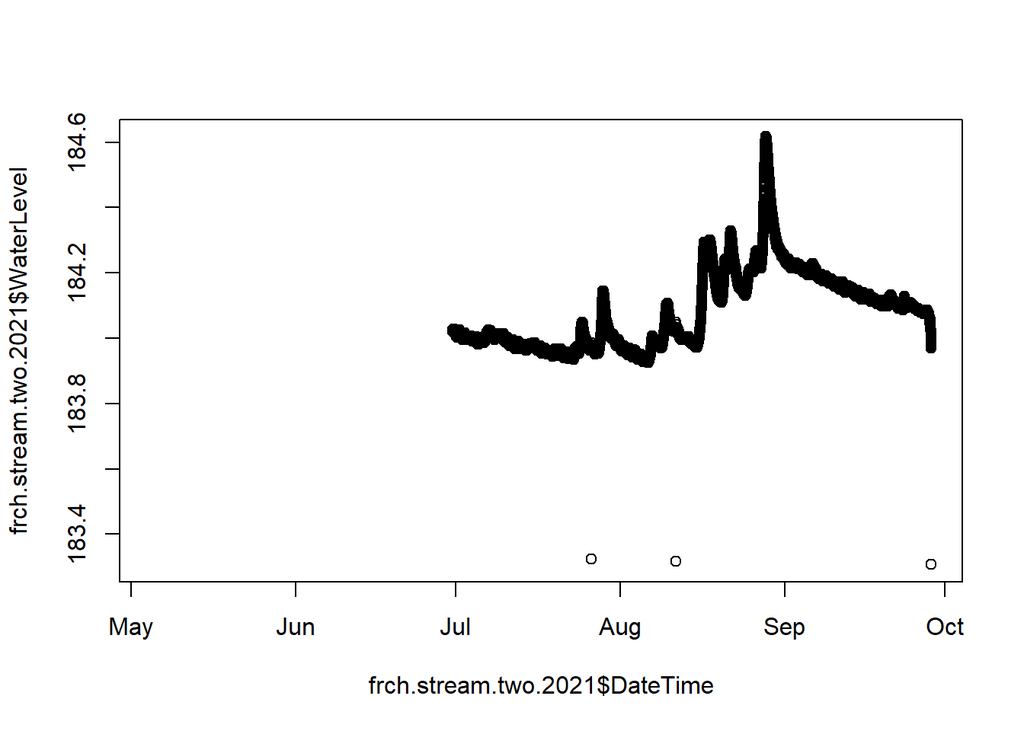

### French PT2 2.0

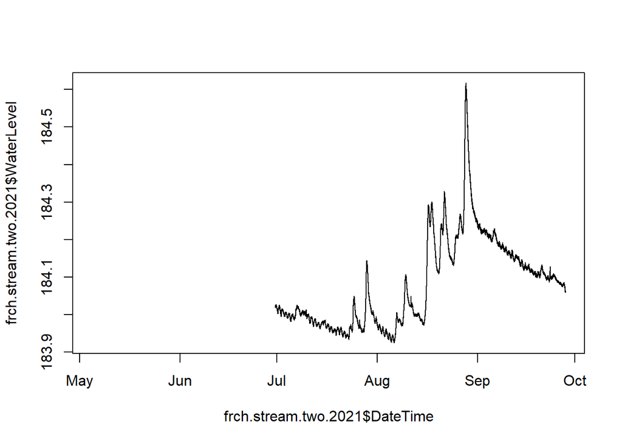

Not too shabby

## Export PT data to csv in DoD_Discharge->PT_data->2021

### Raw Rating curveFrench PT1

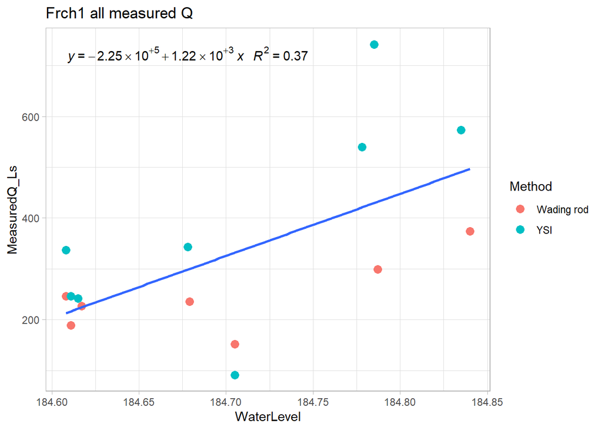

Lets try averaging measurements by date and remove that medium water level, low measured Q point.

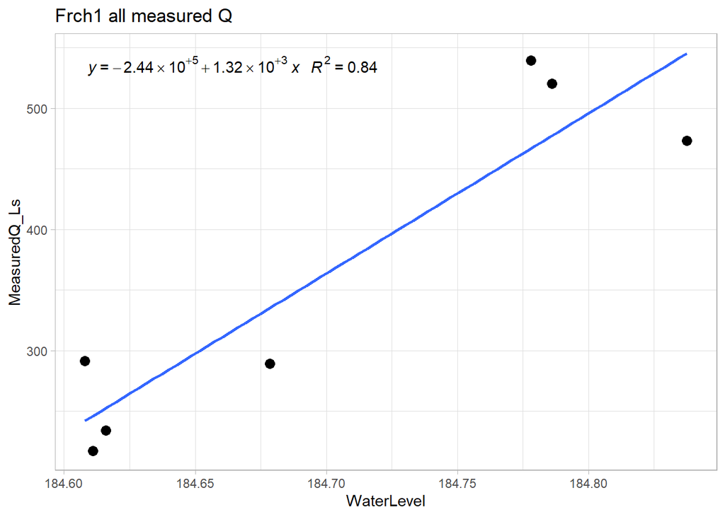

```r
Frch1comb.2021.1 <- Frch1comb.2021 %>% filter(MeasuredQ_Ls > 180) %>% group_by(Date) %>% summarise(MeasuredQ_Ls = mean(MeasuredQ_Ls, na.rm = TRUE),
                                                                    WaterLevel = mean(WaterLevel, na.rm = TRUE),
                                                                    DateTime = min(DateTime, na.rm = TRUE))
FRCH1.lm.2021 <- lm(Frch1comb.2021.1$MeasuredQ_Ls ~ Frch1comb.2021.1$WaterLevel)

ggplot(aes(x = WaterLevel, y = MeasuredQ_Ls), data = Frch1comb.2021.1) +
  geom_point( size = 3) +
  geom_smooth(method = "lm", se=FALSE, formula = frch.formula) +
  stat_poly_eq(formula = frch.formula,
               aes(label = paste(..eq.label.., ..rr.label.., sep = "~~~")),
               parse = TRUE) +
  theme_light() +
  ggtitle("Frch1 all measured Q")
```

### Raw Rating curve French PT2

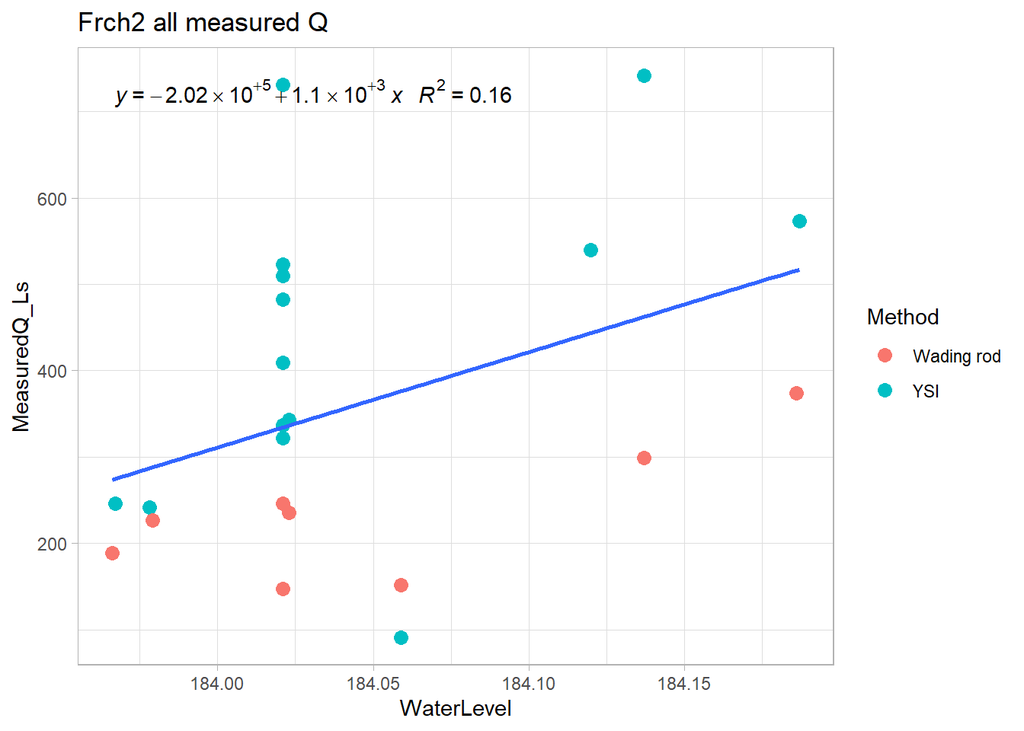

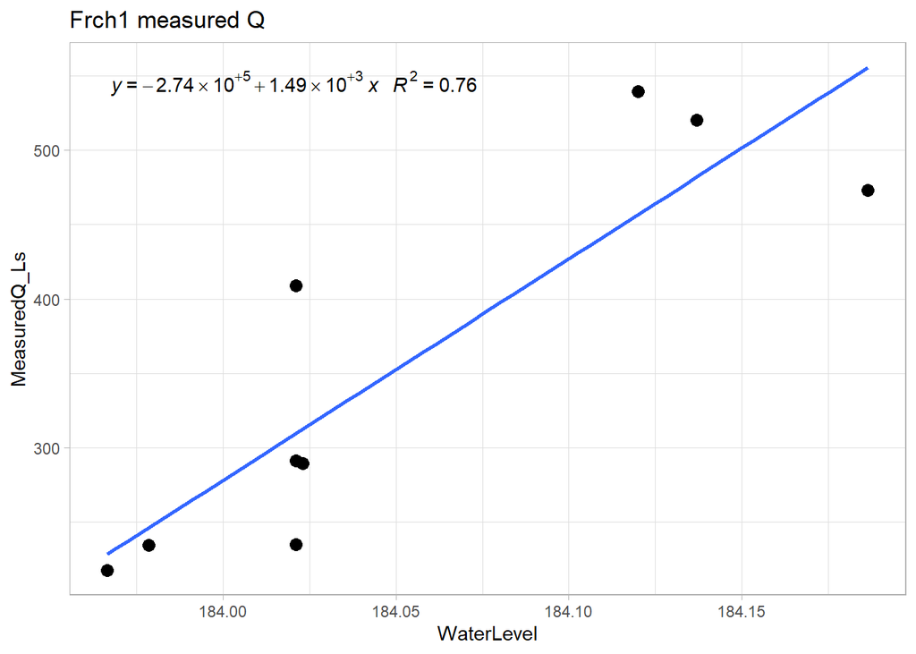

```r
Frch2comb.2021.2 <- Frch2comb.2021 %>% filter(Date != "2021-09-28", MeasuredQ_Ls < 450 | WaterLevel > 184.05) %>% group_by(Date) %>% summarise(MeasuredQ_Ls = mean(MeasuredQ_Ls, na.rm = TRUE),
                                                                   WaterLevel = mean(WaterLevel, na.rm = TRUE),
                                                                   DateTime = min(DateTime, na.rm = TRUE))
FRCH2.lm.2021 <- lm(Frch2comb.2021.2$MeasuredQ_Ls ~ Frch2comb.2021.2$WaterLevel)

frch.formula = y ~ x

ggplot(aes(x = WaterLevel, y = MeasuredQ_Ls), data = Frch2comb.2021.2) +
  geom_point( size = 3) +
  geom_smooth(method = "lm", se=FALSE, formula = frch.formula) +
  stat_poly_eq(formula = frch.formula,
               aes(label = paste(..eq.label.., ..rr.label.., sep = "~~~")),
               parse = TRUE) +
  theme_light() +
  ggtitle("Frch1 measured Q")
```

### Predicted Q FRCH PT1

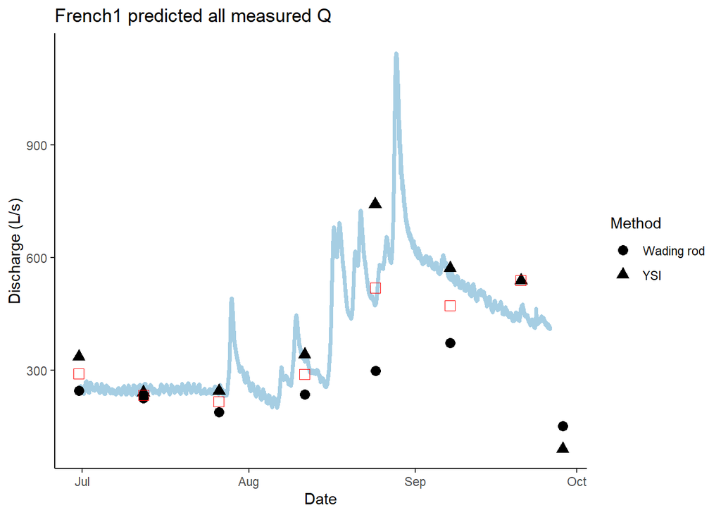

Red points are the averaged points used in the rating curve.

### Predicted Q FRCH PT2

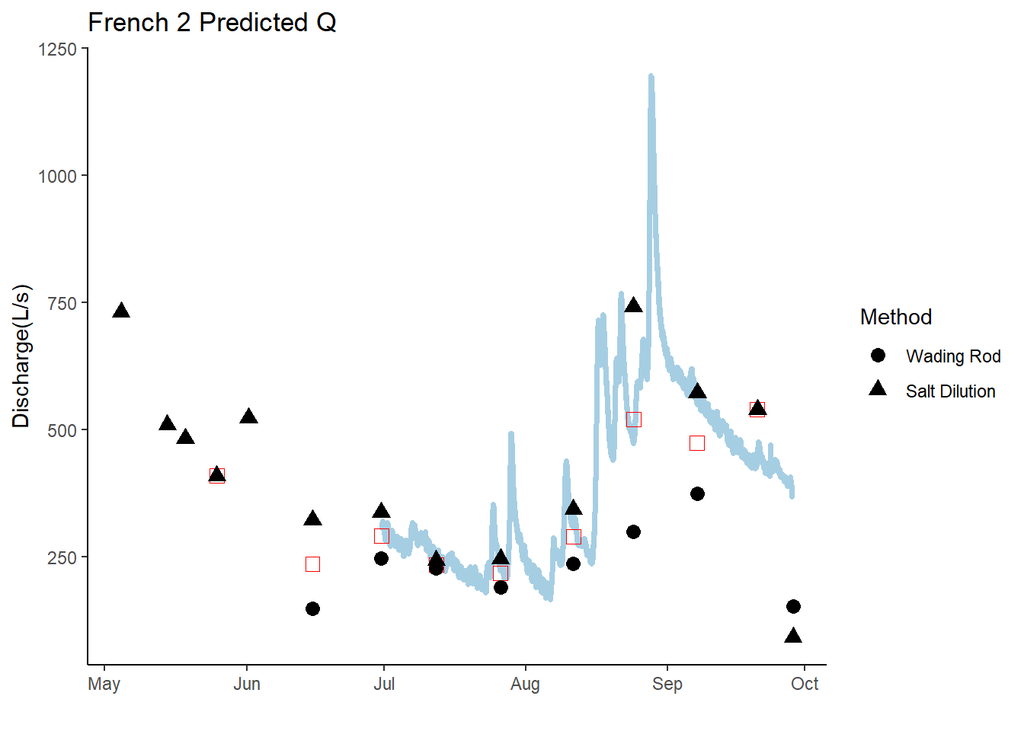

Not too shabby

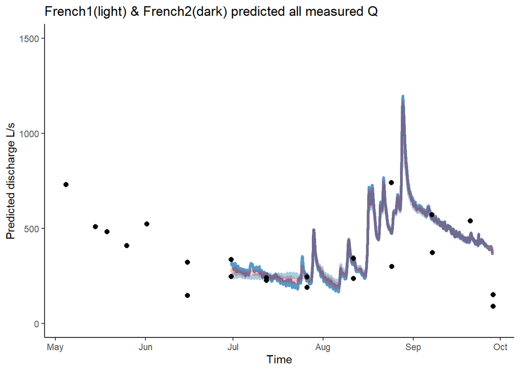

Red should be exported as a csv

## Export PT data to csv in DoD_Discharge->Predicted_discharge->2021

### Raw Poker PT1

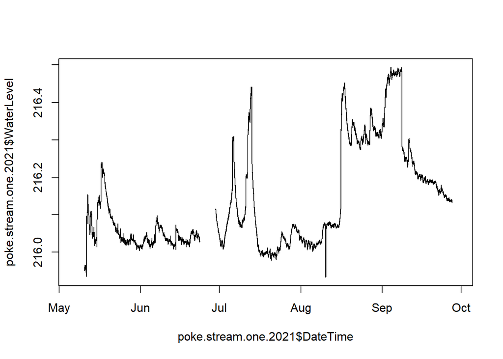

2 beaver dams in July and one in the beginning of september….let the cleaning commence!

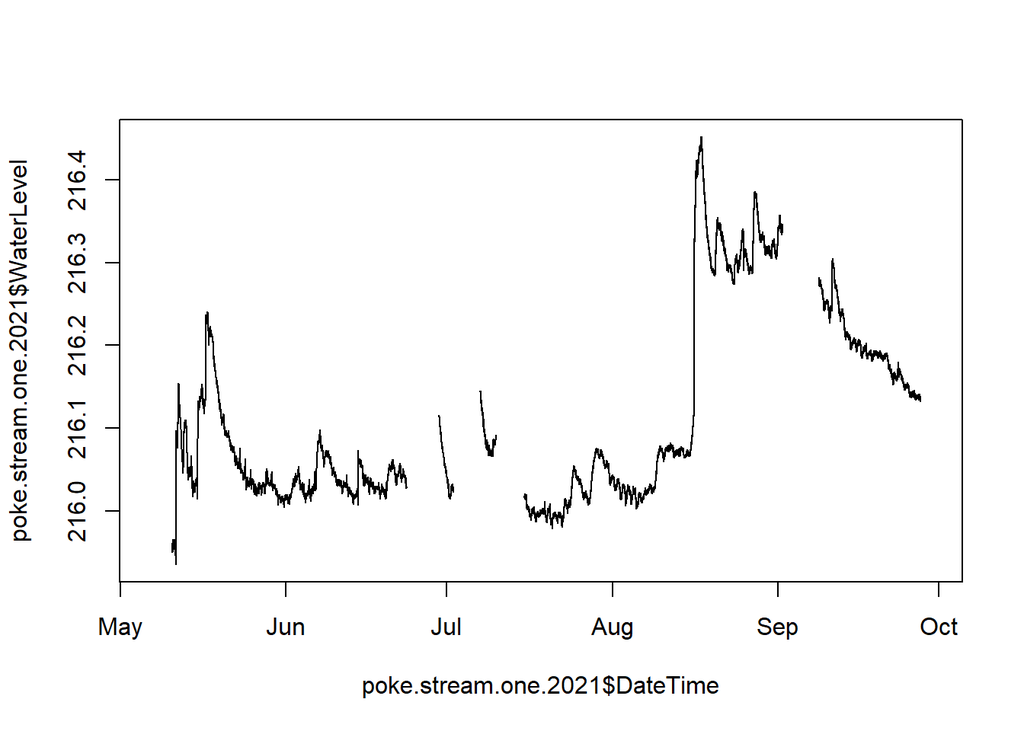

1. Removed beaver dam raise in water level in the beginning, middle of July and beginning of September
2. check the middle of August

### Raw Poker PT2

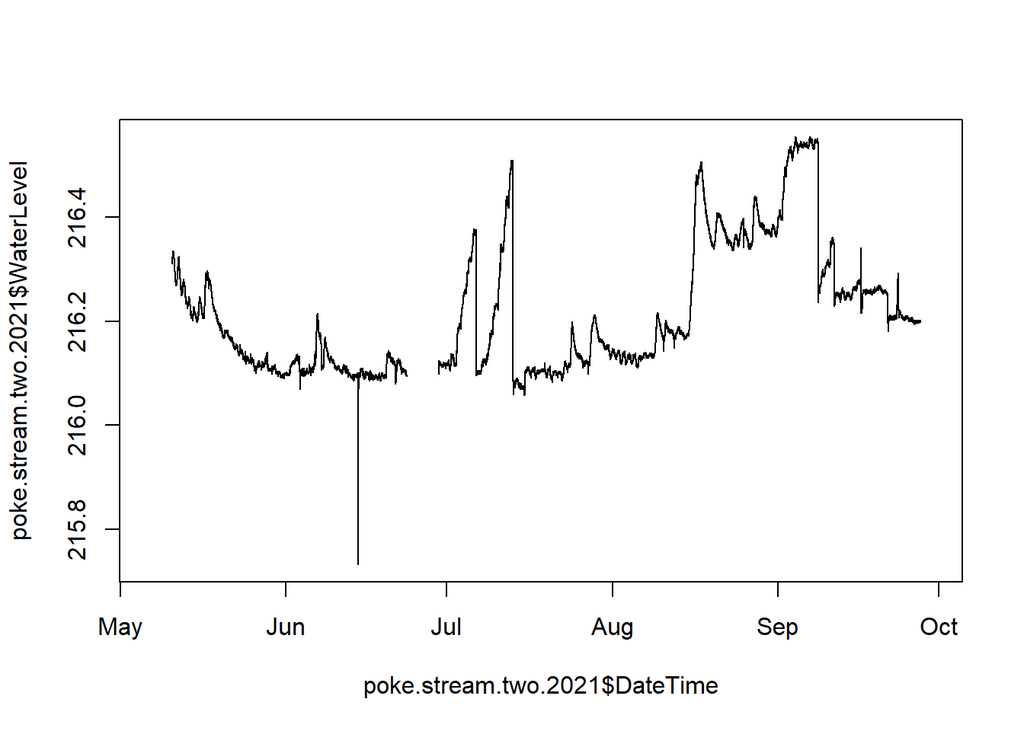

Out of water point in June, beaver dams….let the cleaning commence!

### Poker PT2 2.0

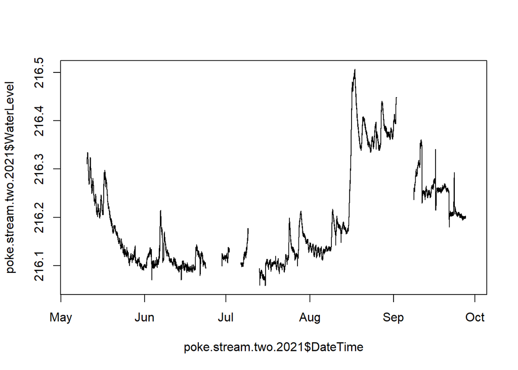

1. Removed beaver dam raise in water level in the beginning, middle of July and beginning of September
2. check the middle of August

## Export PT data to csv in DoD_Discharge->PT_data->2021

### Raw Rating curve Poker PT1

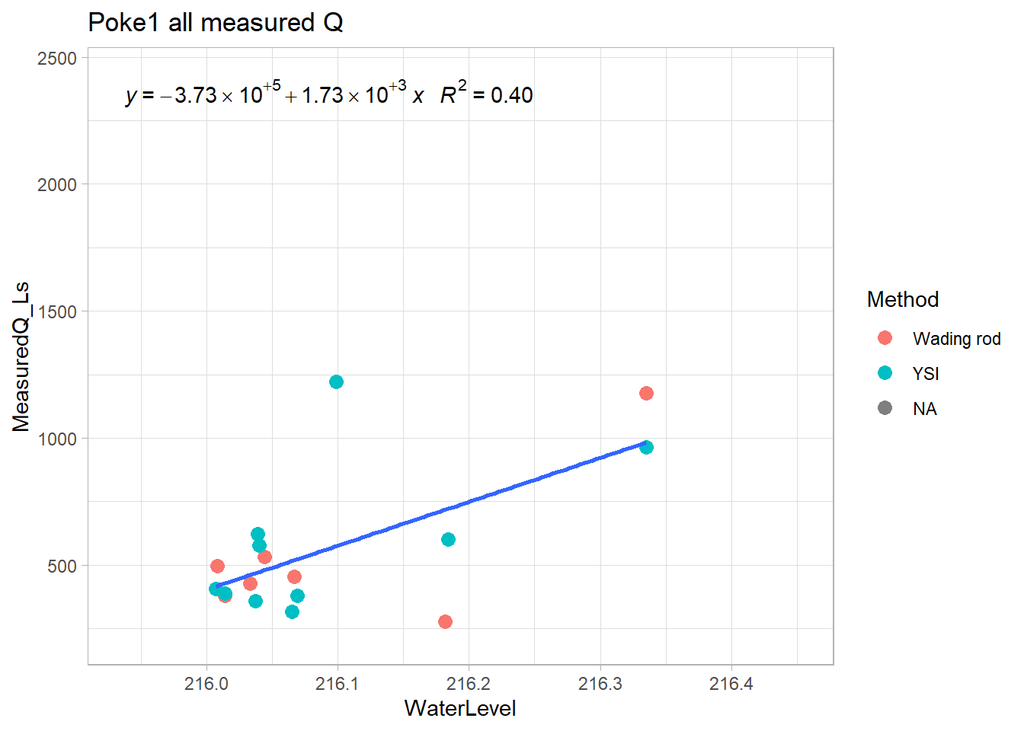

### Rating curve Poker PT1 2.0

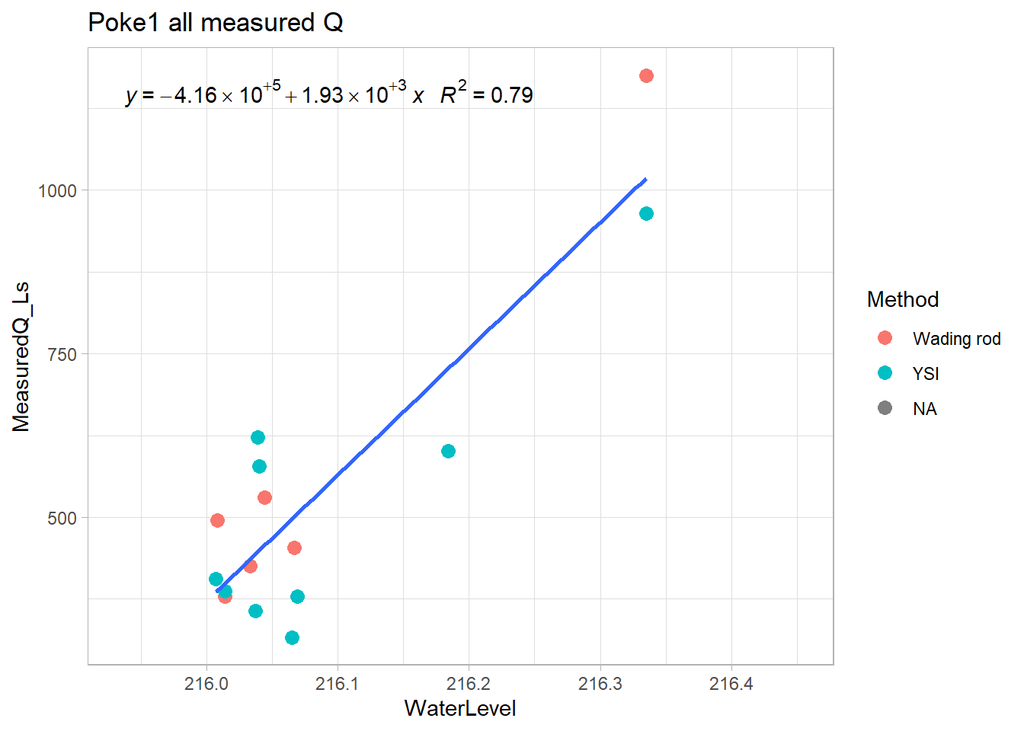

1. Removed highest YSI and
2. Removed lowest Wading rods

### Raw Rating curve Poker PT2

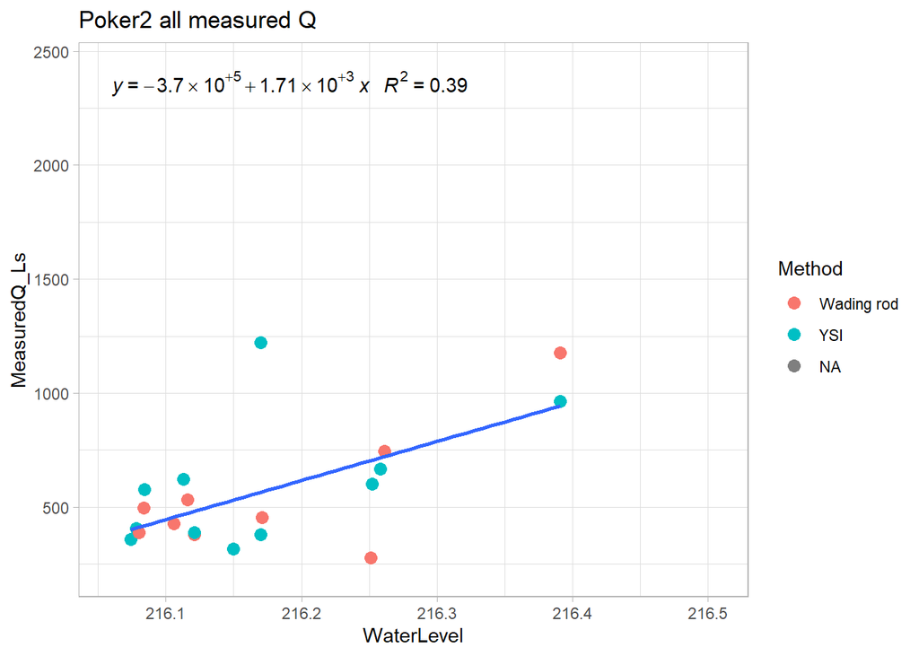

I will remove highest YSI and lowest wading rods

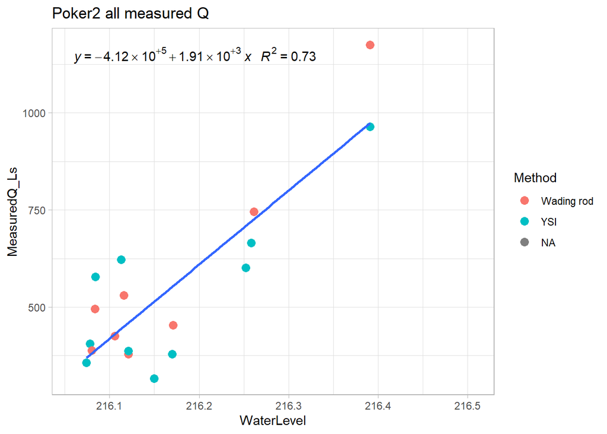

1. Removed highest YSI and
2. Removed lowest Wading rods

### Predicted Q for POKE PT1

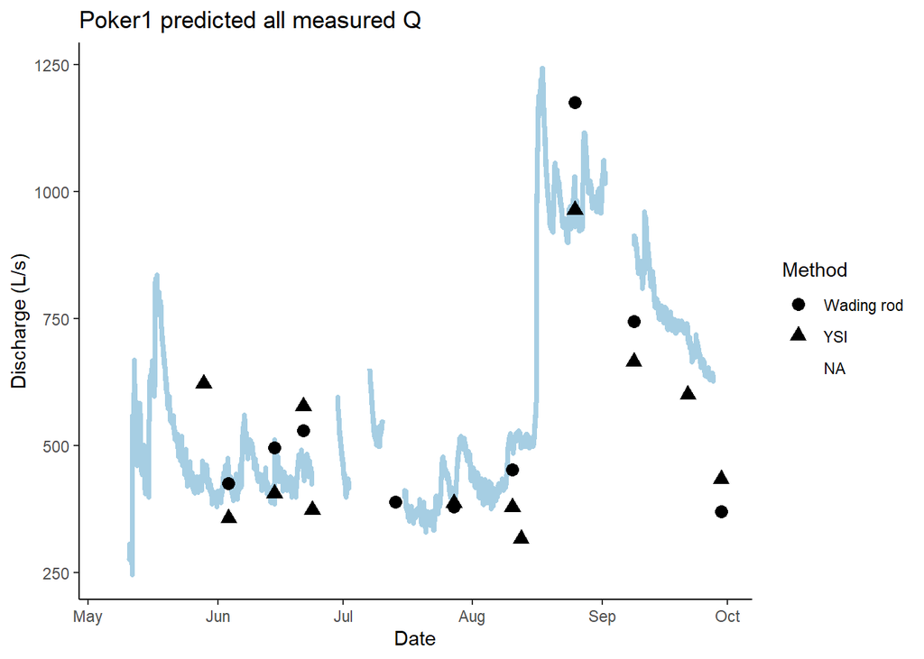

Not the prettiest thing I have ever seen

### Predicted Q for POKE PT2

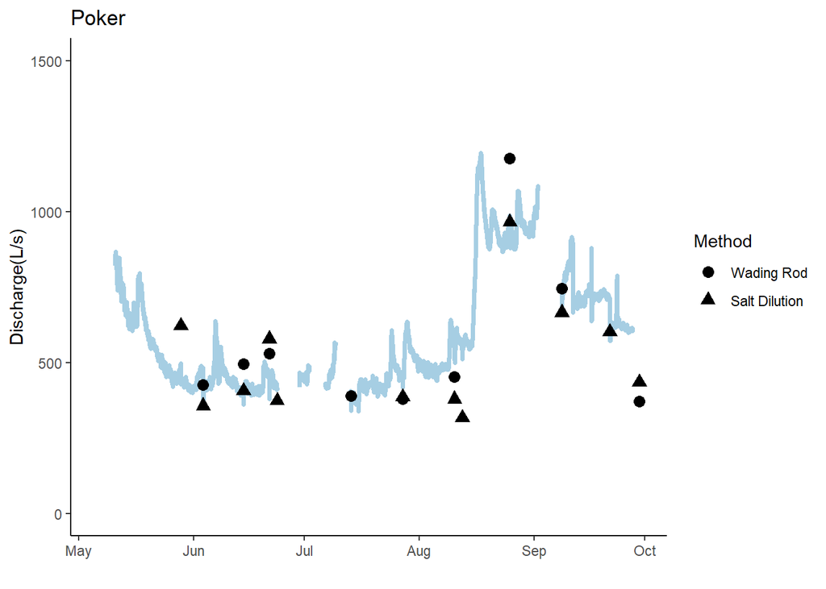

Looks better then PT1…snowmelt signature looks good

### Average Q for POKE

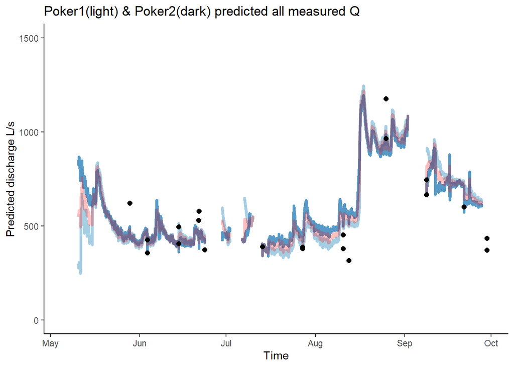

I think I should clip off the beginning of PT1 as the snowmelt signature makes more sense in PT2…what do you think?

Lets use PT2 before May 20th and PT1 only after September 5th.

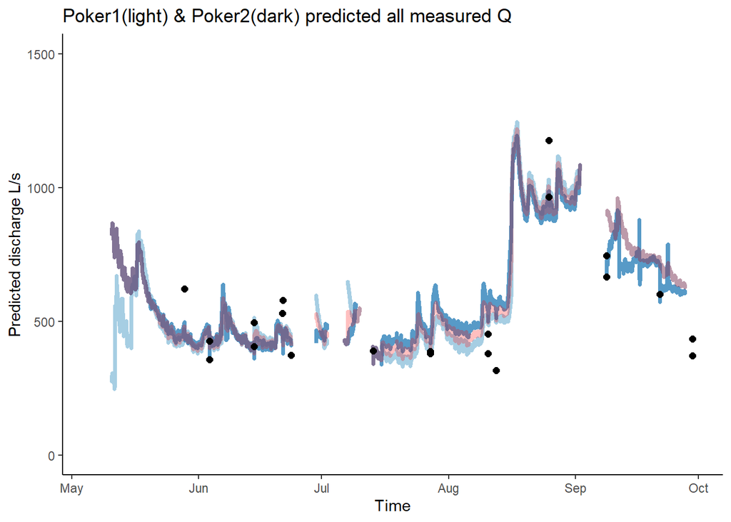

```r
poke.final.discharge.2021.2 <- poke.final.discharge.2021 %>% mutate(across(c(MeanDischarge), ~ifelse(DateTime < "2021-05-20", pred.poke2.Q,.)))

poke.final.discharge.2021.2 <- poke.final.discharge.2021.2 %>% mutate(across(c(MeanDischarge), ~ifelse(DateTime > "2021-09-05", pred.poke1.Q,.)))

# Poker1 (light blue) and Poker2 (dark blue) with observed Q.
ggplot(aes(x = DateTime, y = pred.poke1.Q), data = Poke1comb.2021) +
  geom_line(aes(x = DateTime, y = pred.poke1.Q), data = Poke1comb.2021, color="#A6CEE3", size=1.25) +
  geom_line(aes(x = DateTime, y = pred.poke2.Q), data = Poke2comb.2021,color="#1F78B4", size=1.25, alpha = 0.75) +
  geom_line(aes(x = DateTime, y = MeanDischarge), data = poke.final.discharge.2021.2, color = "red", size = 1.25, alpha = 0.25) +
  geom_point(aes(x = DateTime, y = MeasuredQ_Ls), size=2) +
  theme_classic() +
  ylim(0, 1500) +
  ggtitle("Poker1(light) & Poker2(dark) predicted all measured Q") +
  ylab("Predicted discharge L/s") +
  xlab("Time")
```

## Export PT data to csv in DoD_Discharge->Predicted_discharge->2021

### Raw Vault PT1

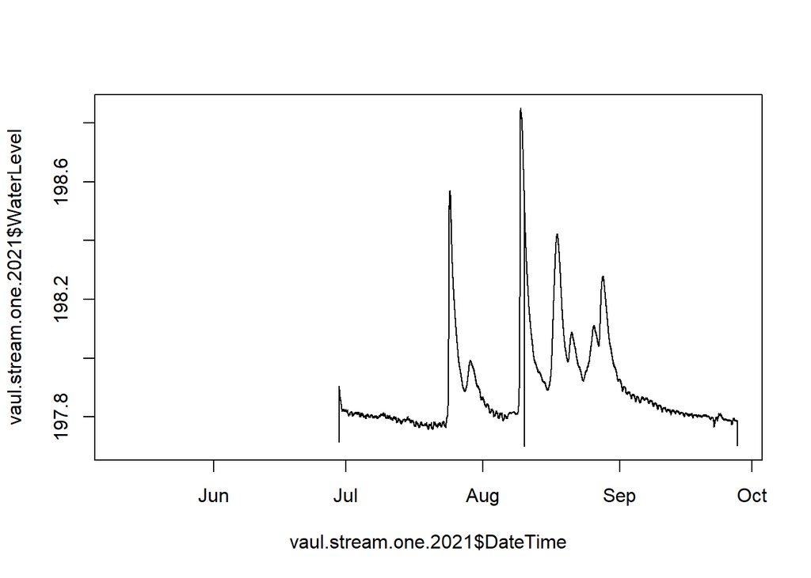

Need to remove vertical bars associated with out of water points such as the beginning and the end of the dataframe

### Vault PT1 2.0

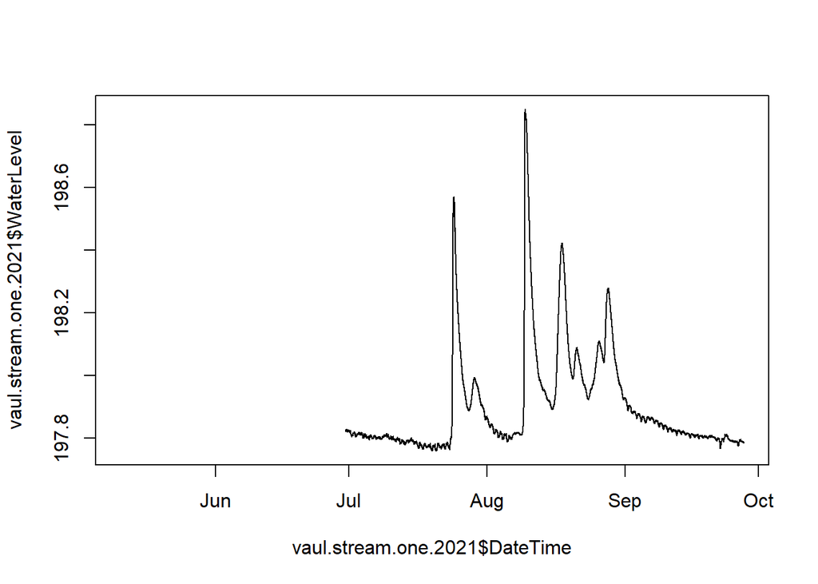

## Export PT data to csv in DoD_Discharge->PT_data->2021

### Raw VAUL rating curve

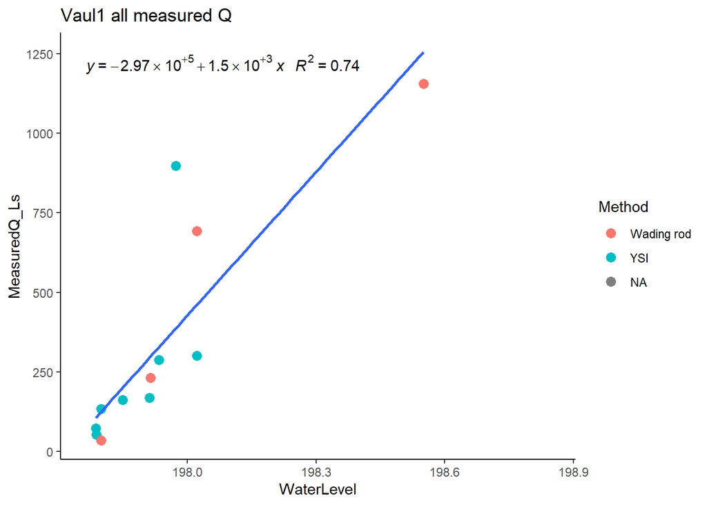

Best raw one yet!

### Predicted Q for VAUL

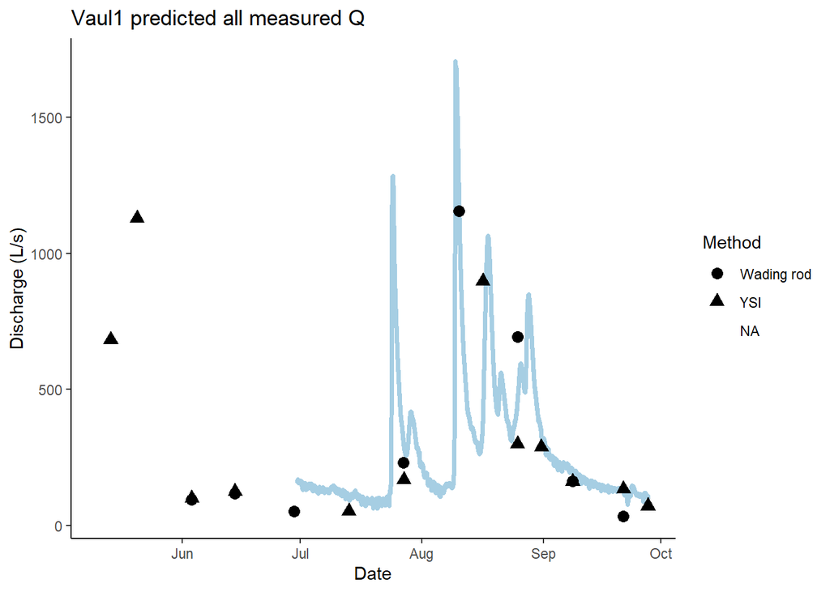

Not too shabby

## Export PT data to csv in DoD_Discharge->Predicted_discharge->2021

### Raw STRT PT1

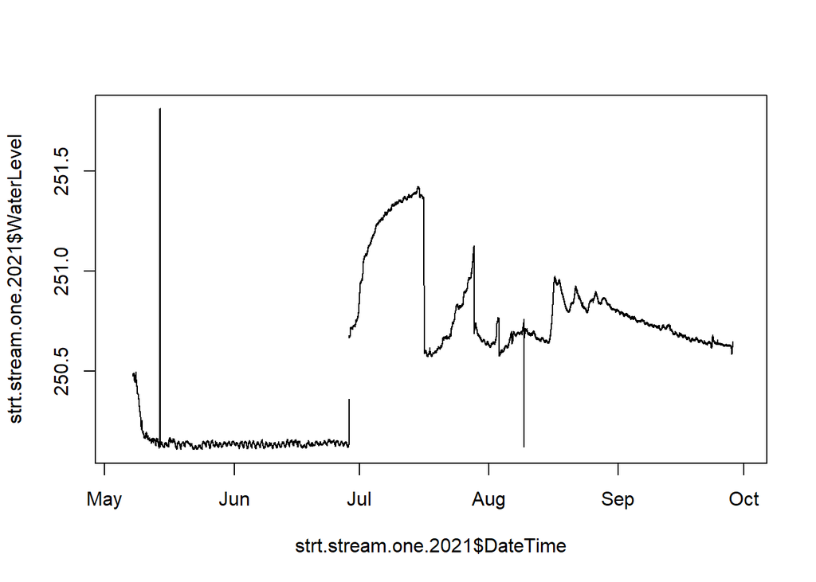

Need to shift beginning of dataframe up and remove beaverr dam in July…remove errant vertical bars

### STRT PT1 2.0

```
## [1] 0.543
```

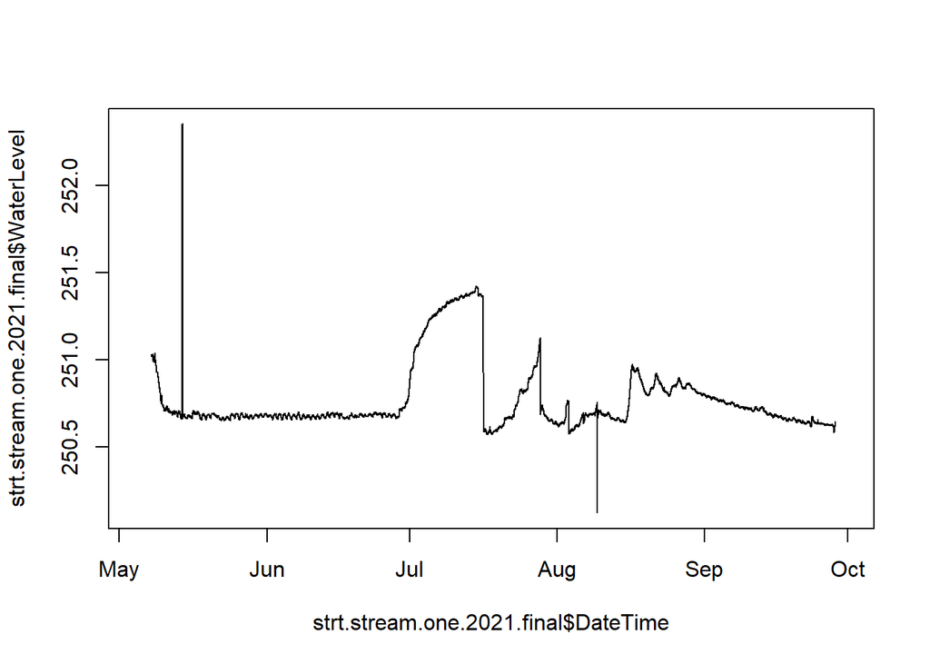

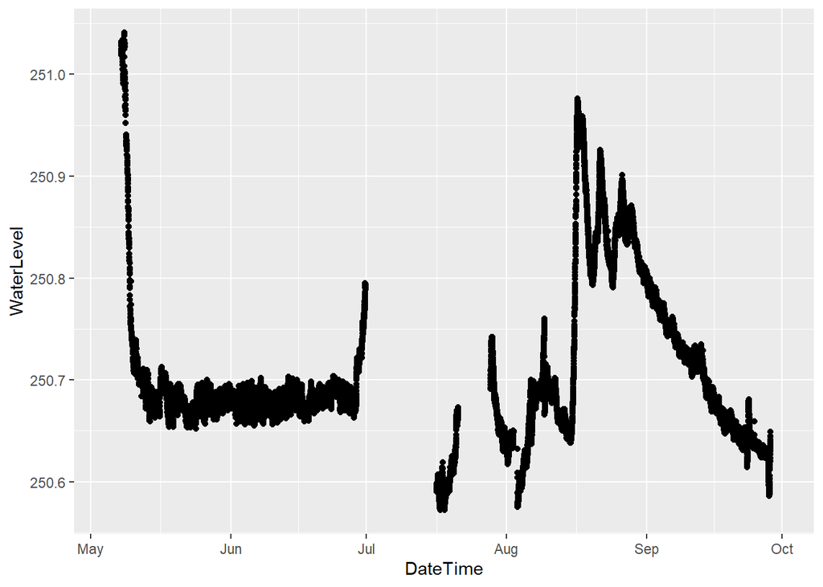

1. Removed errant vertical bar points 2)Removed beaver dam raises in Water level Quick snowmelt period and then not a lot of waterlevel change in June.

### Raw STRT PT2

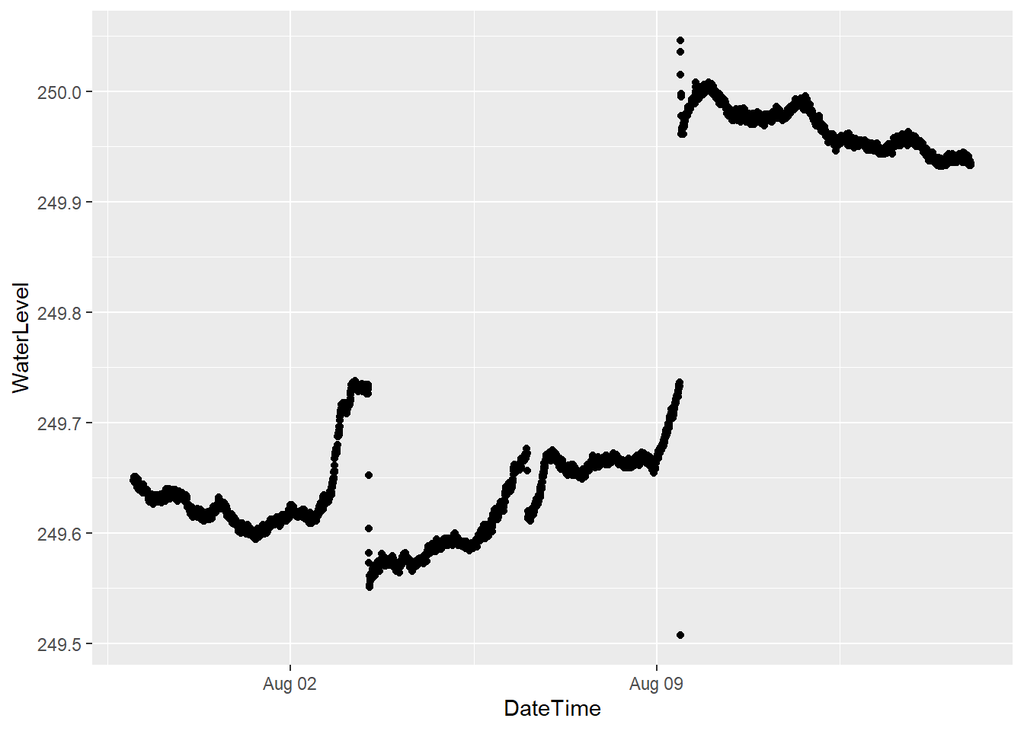

### STRT PT2 2.0

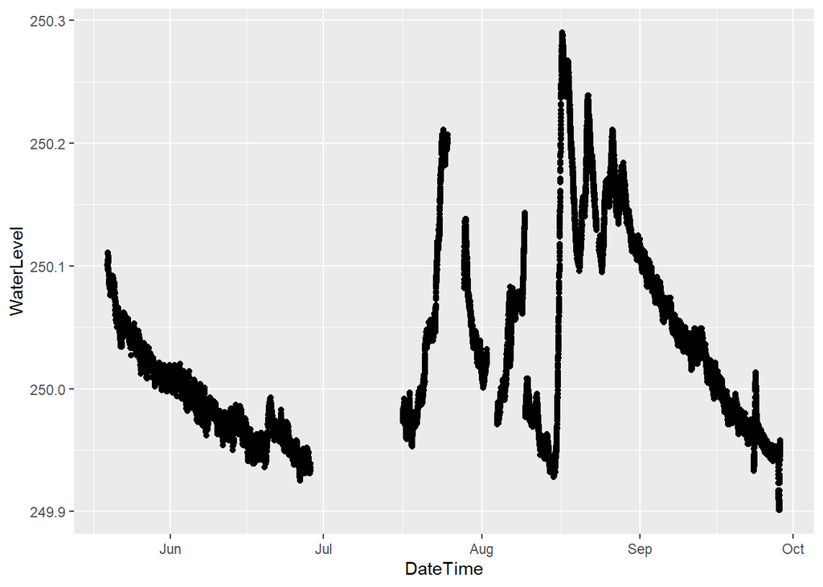

1. removed beaver dams
2. removed errant vertical bars
3. shifted middle of july to middle of August

## Export PT data to csv in DoD_Discharge->PT_data->2021

### Raw STRT rating curve

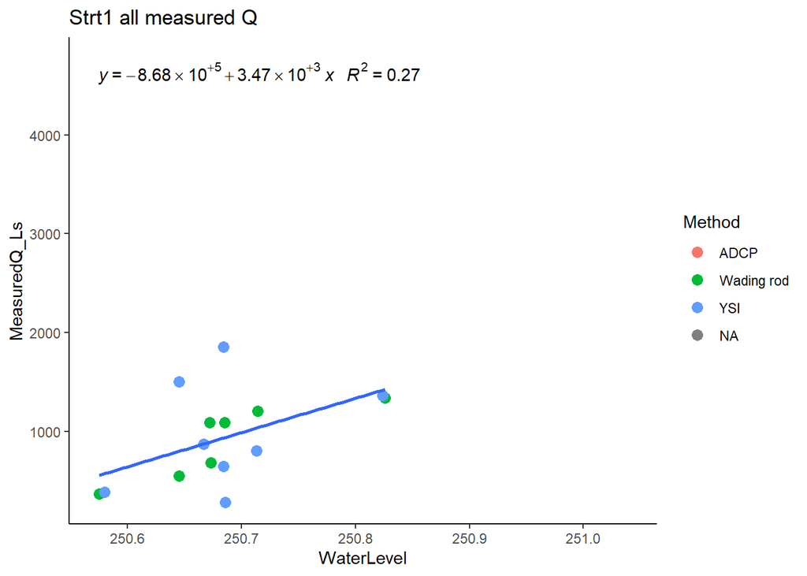

I will remove two high and one low YSI points. ### STRT rating curve 2.0

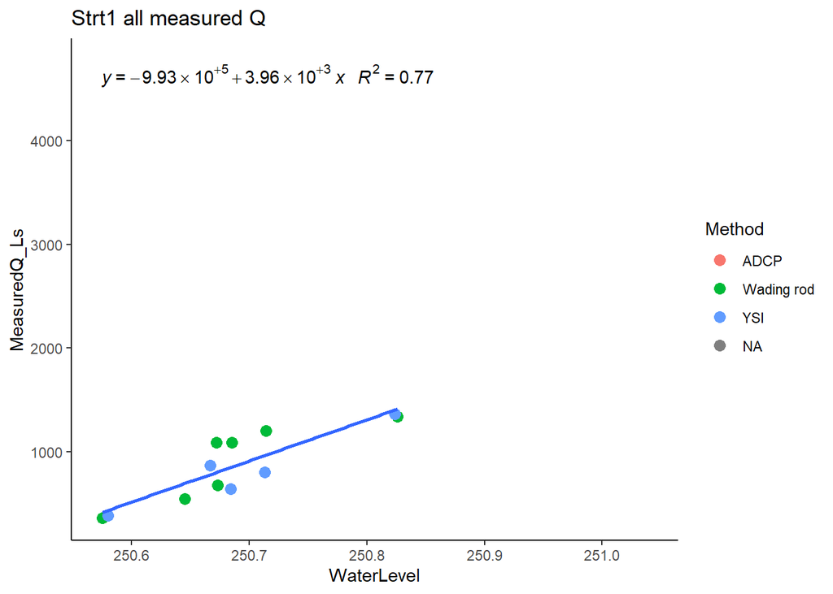

1. Removed highest and lowest YSIs

### Raw STRT rating curve PT2

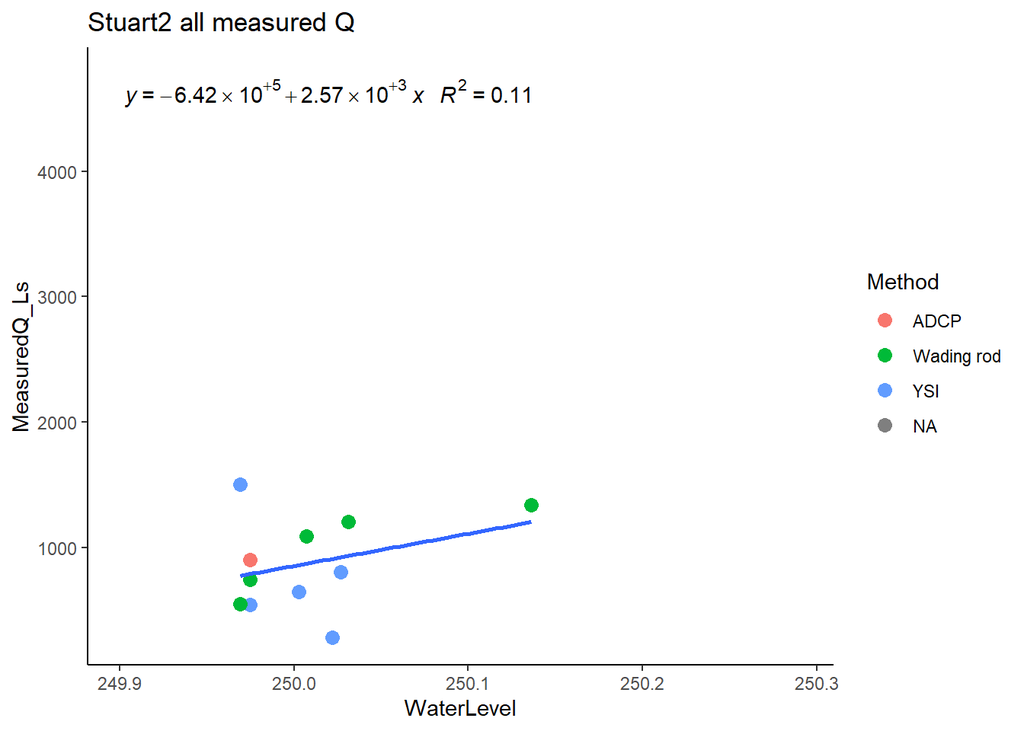

### STRT rating curve PT2 2.0

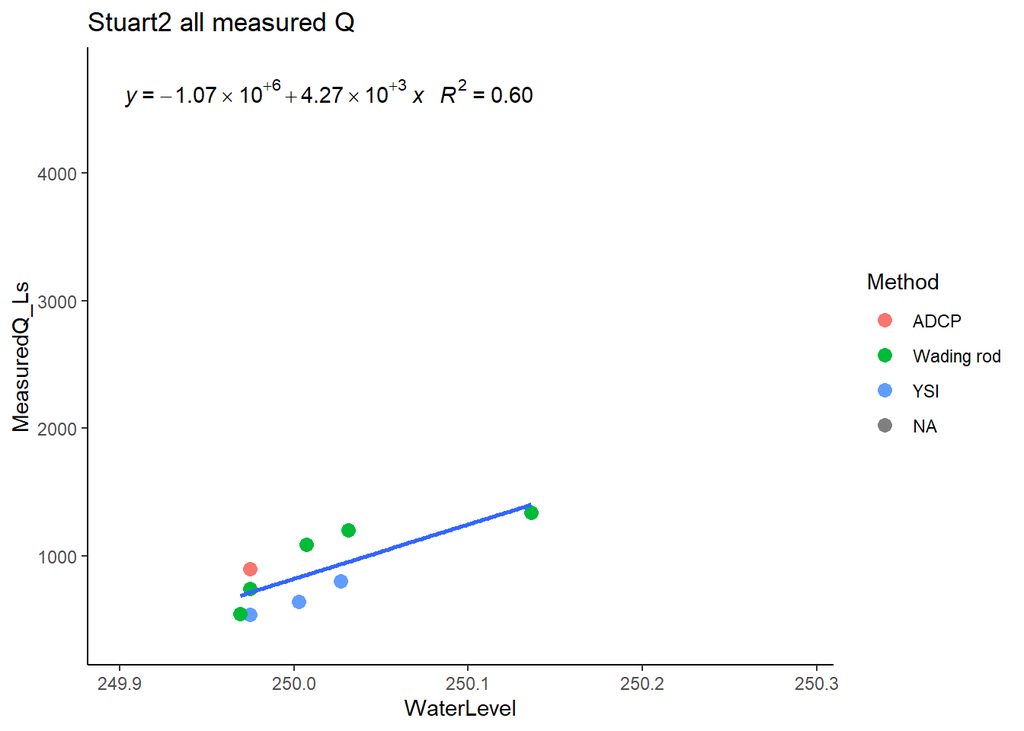

1)Removed lowest and highest YSIs Not as good as PT1

### Predicted Q STRT PT1

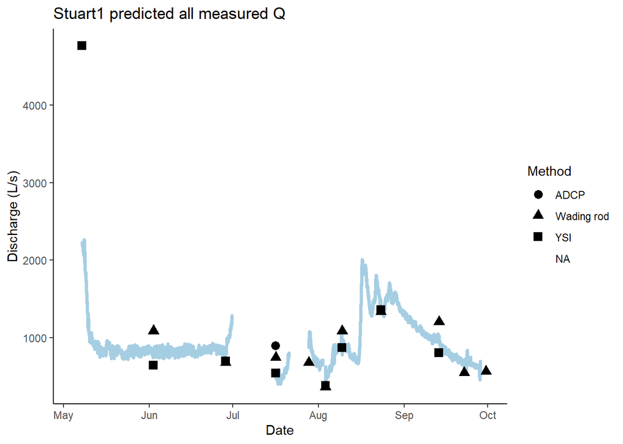

Icky

### Predicted Q STRT PT2

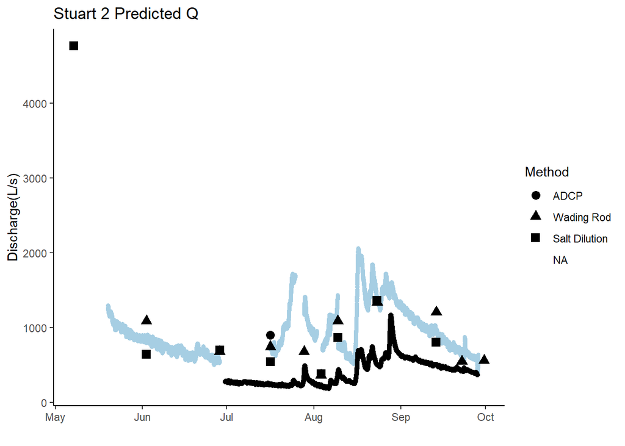

Icky

### Average Q for STRT

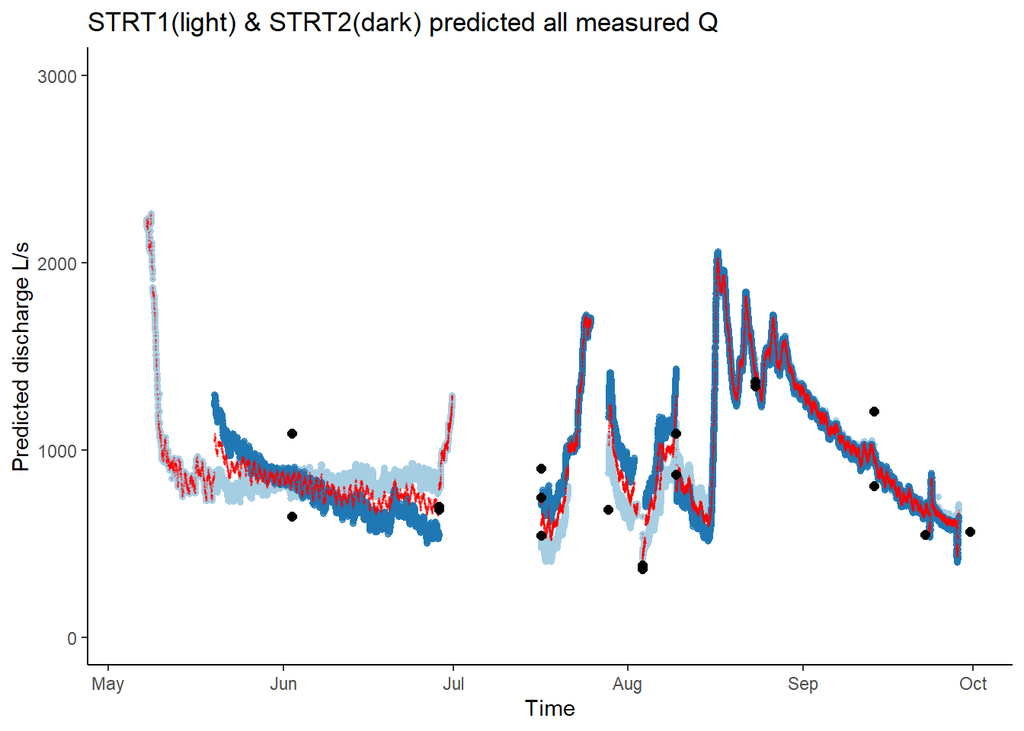

ICKY Lets only use PT1 before July.

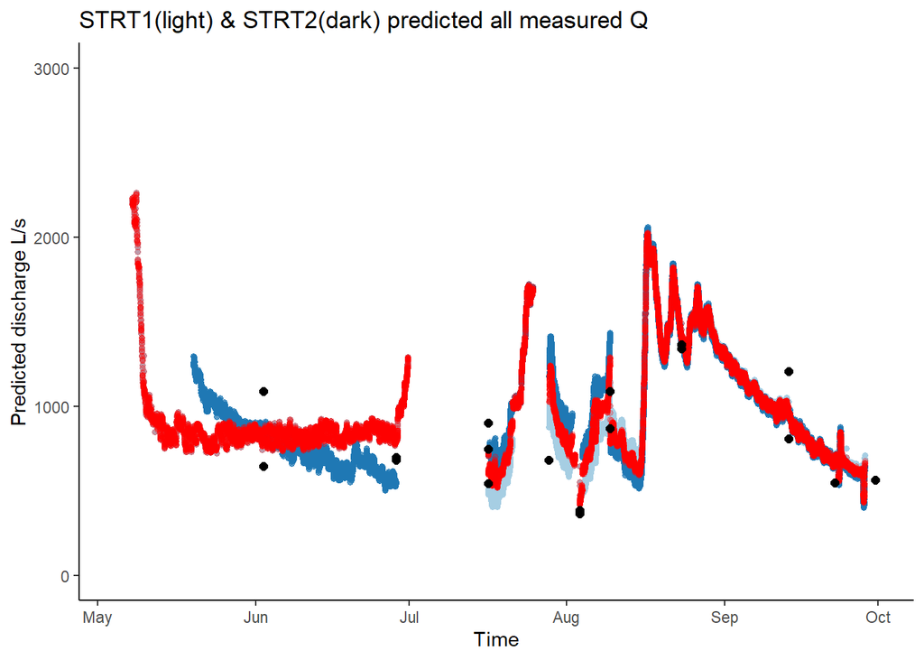

```r
strt.final.discharge.2021 <- strt.final.discharge.2021 %>% mutate(across(c(MeanDischarge), ~ifelse(DateTime < "2021-07-05", pred.strt1.Q,.)))

# Stuart1 (light blue) and Stuart2 (dark blue) with observed Q.
ggplot(aes(x = DateTime, y = pred.strt1.Q), data = Strt1comb.2021) +
  geom_point(aes(x = DateTime, y = pred.strt1.Q), data = Strt1comb.2021, color="#A6CEE3", size=1.25) +
  geom_point(aes(x = DateTime, y = pred.strt2.Q), data = Strt2comb.2021,color="#1F78B4", size=1.25, alpha = 0.75) +
  geom_point(aes(x = DateTime, y = MeanDischarge), data = strt.final.discharge.2021, color = "red", size = 1.25, alpha = 0.25) +
  geom_point(aes(x = DateTime, y = MeasuredQ_Ls), size=2) +
  theme_classic() +
  ylim(0, 3000) +
  ggtitle("STRT1(light) & STRT2(dark) predicted all measured Q") +
  ylab("Predicted discharge L/s") +
  xlab("Time")
```

## Export PT data to csv in DoD_Discharge->Predicted_discharge->2021

## Export PT data to csv in DoD_Discharge->Predicted_discharge->2021